# 2023oct31_deseq2

# ICM 2023OCT20 DESeq2 Script

# UM v IM v H

```r
if (!require("BiocManager", quietly = TRUE))
    install.packages("BiocManager")

BiocManager::install(c("circlize", "corrplot", "dendextend","readr","DESeq2","vsn", "ggfortify", "ggrepel", "ggplot2", "pheatmap", "devtools", "ggforce","pheatmap", "gplots", "RColorBrewer", "ggdendro", "magrittr","apeglm"))
a
setwd("~/Desktop/Lab/Working_Projects/trapseq_2023")


library(readr)
featcount <- read_table("featcount.txt",
                        col_names = TRUE, skip = 1)
read.count <- data.frame(featcount, row.names = featcount$Geneid ) #gene ids stored as row names
geneID<- featcount$Geneid

read.count <- read.count [ ,-c(1:6)] #removes the columns without gene counts not the same as bottom row code

orig_names <- names(read.count)
#print(orig_names)

colnames(read.count) <- (c("IT-107","IT-108", "IT-109", "IT-110", "H-107", "H-108", "H-109", "H-110","H-111", "UT-106", "UT-108", "UT-114", "IT-206", "IT-207", "IT-208", "IT-209", "IM-206", "IM-207", "IM-208", "IM-209", "IM-210", "UT-204", "UT-208", "UT-213", "UT-214", "UM-204", "UM-208", "UM-213", "UM-214", "UM-215"))
#view(read.count)


ImvHvUM <- read.count [ ,-c(1:4, 10:16,22:25)]

sample_info <- data.frame(
  sample = c( "H-107", "H-108", "H-109", "H-110","H-111","IM-206", "IM-207", "IM-208", "IM-209", "IM-210","UM-204", "UM-208", "UM-213", "UM-214", "UM-215" ),
  groups=c( "H", "H", "H", "H","H", "IM", "IM", "IM", "IM", "IM","UM","UM","UM","UM","UM"),
  condition =c("Infected","Infected","Infected","Infected","Infected","Infected","Infected","Infected","Infected","Infected", "Uninfected","Uninfected","Uninfected","Uninfected","Uninfected"),
  replicate= c("H-107", "H-108", "H-109", "H-110","H-111", "IM-206", "IM-207", "IM-208", "IM-209", "IM-210","UM-204", "UM-208", "UM-213", "UM-214", "UM-215"),
  row.names = "sample")


metadata <- as.data.frame.array(sample_info)

all(rownames(metadata) %in% colnames(ImvHvUM))
```

```
[1] TRUE
```

```r
sample_info$groups<- as.factor(sample_info$groups)
all(rownames(sample_info) %in% colnames(ImvHvUM)) #if false something is wrong
```

```
[1] TRUE
```

```r
sample_info
```

|  | groups | condition | replicate |
| --- | --- | --- | --- |
| H-107 | H | Infected | H-107 |
| H-108 | H | Infected | H-108 |
| H-109 | H | Infected | H-109 |
| H-110 | H | Infected | H-110 |
| H-111 | H | Infected | H-111 |
| IM-206 | IM | Infected | IM-206 |
| IM-207 | IM | Infected | IM-207 |
| IM-208 | IM | Infected | IM-208 |
| IM-209 | IM | Infected | IM-209 |
| IM-210 | IM | Infected | IM-210 |

[output cut: 5 more lines]

```r
library(DESeq2)

dds <- DESeqDataSetFromMatrix(countData = ImvHvUM,
                              colData = sample_info,
                              design = ~condition)
```

```
Warning: some variables in design formula are characters, converting to factors
```

```r
print(dds)
```

```
class: DESeqDataSet
dim: 38295 15
metadata(1): version
assays(1): counts
rownames(38295): AT1G01010 AT1G01020 ... ArthCp084 ArthCp085
rowData names(0):
colnames(15): H-107 H-108 ... UM-214 UM-215
colData names(3): groups condition replicate
```

```r
library(magrittr)
#prefiltering
dds <- (dds[ rowSums( counts(dds) ) > 10 , ])

dds$groups<-relevel(dds$groups, ref = "UM")
dds$groups
```

```
 [1] H  H  H  H  H  IM IM IM IM IM UM UM UM UM UM
Levels: UM H IM
```

```r
summary(dds$groups)
```

```
UM  H IM
 5  5  5
```

```r
#VST is offered as separate functionality which can be used for visualization, clustering or other machine learning tasks.

library(vsn)

vsd <- vst(dds, blind = TRUE )
```

#with plotpca i CAN use rld as is

```r
# PCA
library(gplots)
library(RColorBrewer)
library(corrplot)
library(ggdendro)
library(magrittr)
library(dendextend)
pcadata<- plotPCA(vsd, intgroup=c("replicate","groups"), ntop=5000, returnData = TRUE)
```

```
using ntop=5000 top features by variance
```

```r
summary(pcadata)
```

```
      PC1              PC2               group    replicate         groups     name
 Min.   :-87.64   Min.   :-37.69   H-107:H  :1   Length:15          UM:5   Length:15
 1st Qu.:-60.84   1st Qu.:-22.81   H-108:H  :1   Class :character   H :5   Class :character
 Median :-44.43   Median :-11.91   H-109:H  :1   Mode  :character   IM:5   Mode  :character
 Mean   :  0.00   Mean   :  0.00   H-110:H  :1
 3rd Qu.: 98.96   3rd Qu.: 28.35   H-111:H  :1
 Max.   :121.22   Max.   : 41.06   IM-206:IM:1
                                   (Other)  :9
```

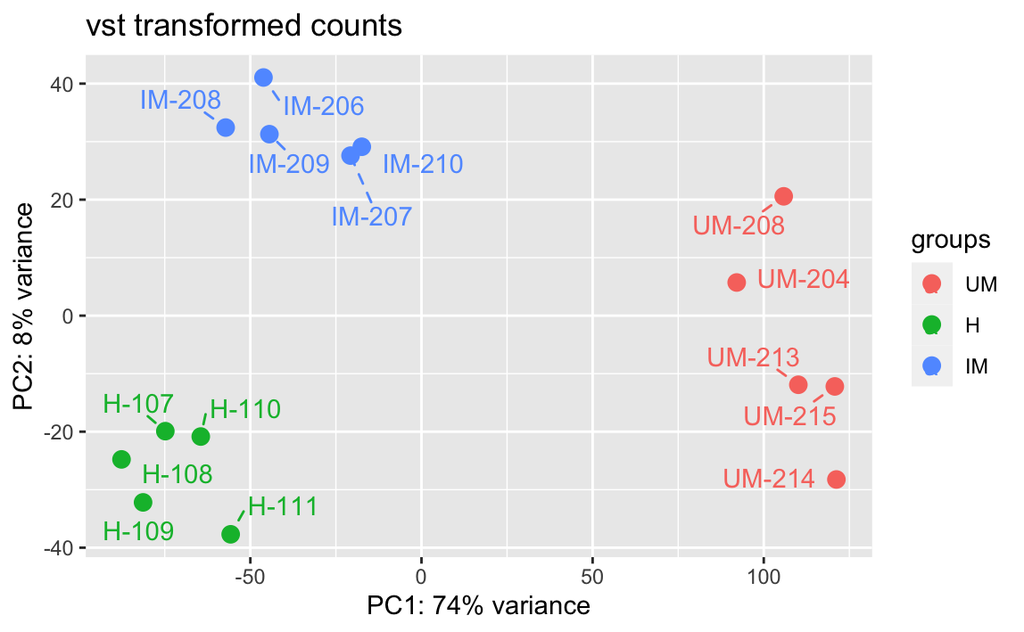

```r
percentVar <- round(100 * attr(pcadata, "percentVar"))

p <- ggplot(pcadata, aes(PC1,PC2, label = replicate, colour = groups )) +
  geom_point(size=3)

p2 <- p + geom_text_repel(box.padding = 0.5, max.overlaps = 15, segment.linetype = 2) + labs(title = "vst transformed counts") +
  xlab(paste0("PC1: ",percentVar[1],"% variance")) +
  ylab(paste0("PC2: ",percentVar[2],"% variance"))
p2
```

```r
#ggsave("PCA_5000.png")
#saved as of 11.26.2023
```

######Pairwise correlation cor() #The Pearson correlation coefficient, r, is a measure of the strength of the linear relationship between two variables and is often used to assess the similarity of RNA-seq samples in a pair-wise fashion. It is defined as the covariance of two variables divided by the product of their standard deviation.

######Hierarchical clustering #To determine whether the different sample types can be separated in an unsupervised fashion (i.e., samples of different conditions are more dissimilar to each other than replicates within the same condition) Hierarchical clustering is typically based on pairwise comparisons of individual samples, which are grouped into “neighborhoods” of similar samples. The basis of hierarchical clustering is therefore a matrix of similarity metrics (which is different from the actual gene expression values!). #Hierarchical clustering requires two decisions: # 1. How should the (dis)similarity between pairs be calculated? # 2. How should the (dis)similarity be used for the clustering? #A common way to assess the (dis)similarity is the Pearson correlation coefficient, r, that we just described. The corresponding distance measure is d = 1 − r.

#Decide on how the distances should be used to define clusters of samples. The most popular choices for the linkage function are # complete: intercluster distance ≡ largest distance between any 2 members of either cluster # average: intercluster distance ≡ average distance between any 2 members # single: intercluster distance ≡ shortest distance between any 2 members